# Analise dos dados ‘iris’

Carolina Musso

2023-11-28

## Introdução (Veja que isso vira um subtítulo no documento final)

Este relatório tem como foco a análise da renomada base de dados Iris, um conjunto de dados clássico no campo da estatística. Originalmente coletada pelo botânico Edgar Anderson e popularizada pelo estatístico Ronald Fisher, a base de dados Iris consiste em 150 observações de três espécies de íris (Iris setosa, Iris virginica e Iris versicolor). Cada observação registra quatro características das flores: o comprimento e a largura da sépala, e o comprimento e a largura da pétala.

Neste relatório, empregaremos técnicas de análise exploratória de dados para extrair insights valiosos sobre as características dessas espécies de íris. Além disso, exploraremos como diferentes métodos de visualização de dados podem ser utilizados para compreender melhor as relações entre as variáveis. O objetivo é proporcionar uma compreensão abrangente da base de dados Iris, servindo como um ponto de referência para futuras análises e utilização de relatórios automatizados.

# Material e métodos

# Resultados

Um gráfico clássico.

Podemos observar a média de área da pétala das espécies na Figura 1. A espécie com maior área média da pétala é a virginica com 4.96 cm$^2$.

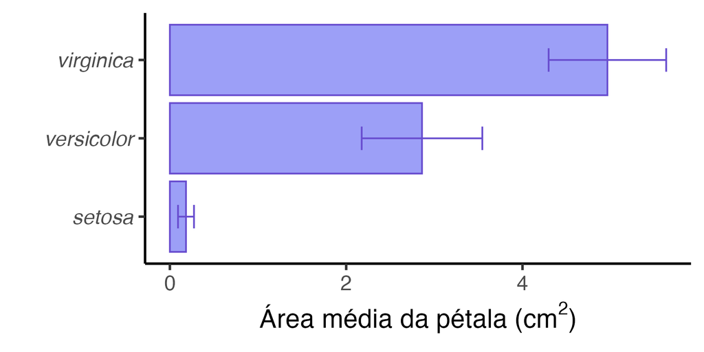

Figure 1: Gráfico de barras com a média da área da pétala para cada espécie de íris.

Uma tabela resumo 1.

Table 1: **Estatísticas Descritivas das Variáveis de Íris por Espécie**

| **Variável (cm)** | **setosa**, N = 50<sup>1</sup> | **versicolor**, N = 50<sup>1</sup> | **virginica**, N = 50<sup>1</sup> |
| --- | --- | --- | --- |
| Comprimento da Sépala | 5.01 (0.35) | 5.94 (0.52) | 6.59 (0.64) |
| Largura da Sépala | 3.43 (0.38) | 2.77 (0.31) | 2.97 (0.32) |
| Comprimento da Pétala | 1.46 (0.17) | 4.26 (0.47) | 5.55 (0.55) |
| Largura da Pétala | 0.25 (0.11) | 1.33 (0.20) | 2.03 (0.27) |

<sup>1</sup> Mean (SD)

## Gráficos e testes

Tente repetir o que foi feito antes para inserir a referencia cruzada do texto com a prxuma figura.

[figure not shown]

Figure 2: Gráfico de dispersão com linha de regressão e intervalo de confiança para cada espécie de íris.

# Exercício para a segunda aula